# Cyclistic Bike-Share Analysis Notebook

Shrabana Nandi

November 13, 2025

# BUSINESS TASK

**Goal:** Convert casual riders into annual members

**Core Questions:** 1. How do annual members and casual riders use Cyclistic bikes differently?  
2. Why might casual riders buy annual memberships?  
3. How can Cyclistic use digital media to influence conversion?

🧭 *The plan:* Explore patterns in usage (time, distance, frequency, and stations) and identify behavioral cues that could drive marketing actions.

# DATA SOURCE

Cyclistic bike share trip data from Q1 2019 and Q1 2020.

# DATA UPLOAD & CLEANING

First, load the essentials. These will handle wrangling, cleaning, and plotting.

```r
library(tidyverse)
library(lubridate)
library(janitor)
library(skimr)
library(readr)
library(dplyr)
```

💭 *Thoughts:* No need to go overboard — **tidyverse** covers most cleaning and analysis. `janitor` will clean column names, and `skimr` gives a quick glance at structure.

### Importing Datasets

```r
divvy_2019 <- read_csv("D:/COURSERA/GOOGLE ANALYTICS/COURSE 8/Divvy_Trips_2019_Q1 - Divvy_Trips_2019_Q1.csv")
divvy_2020 <- read_csv("D:/COURSERA/GOOGLE ANALYTICS/COURSE 8/Divvy_Trips_2020_Q1 - Divvy_Trips_2020_Q1.csv")
head(divvy_2019)
```

| trip_id | start_time | end_time | bikeid | tripduration | from_station_id | from_station_name | to_station_id | to_station_name | usertype | gender | birthyear |
| --- | --- | --- | --- | --- | --- | --- | --- | --- | --- | --- | --- |
| 21742443 | 2019-01-01 0:04:37 | 2019-01-01 0:11:07 | 2167 | 390 | 199 | Wabash Ave & Grand Ave | 84 | Milwaukee Ave & Grand Ave | Subscriber | Male | 1989 |
| 21742444 | 2019-01-01 0:08:13 | 2019-01-01 0:15:34 | 4386 | 441 | 44 | State St & Randolph St | 624 | Dearborn St & Van Buren St (*) | Subscriber | Female | 1990 |
| 21742445 | 2019-01-01 0:13:23 | 2019-01-01 0:27:12 | 1524 | 829 | 15 | Racine Ave & 18th St | 644 | Western Ave & Fillmore St (*) | Subscriber | Female | 1994 |
| 21742446 | 2019-01-01 0:13:45 | 2019-01-01 0:43:28 | 252 | 1783 | 123 | California Ave & Milwaukee Ave | 176 | Clark St & Elm St | Subscriber | Male | 1993 |
| 21742447 | 2019-01-01 0:14:52 | 2019-01-01 0:20:56 | 1170 | 364 | 173 | Mies van der Rohe Way & Chicago Ave | 35 | Streeter Dr & Grand Ave | Subscriber | Male | 1994 |
| 21742448 | 2019-01-01 0:15:33 | 2019-01-01 0:19:09 | 2437 | 216 | 98 | LaSalle St & Washington St | 49 | Dearborn St & Monroe St | Subscriber | Female | 1983 |

```r
head(divvy_2020)
```

| ride_id | rideable_type | started_at | ended_at | start_station_name | start_station_id | end_station_name | end_station_id | start_lat | start_lng | end_lat | end_lng | member_casual |
| --- | --- | --- | --- | --- | --- | --- | --- | --- | --- | --- | --- | --- |
| EACB19130B0CDA4A | docked_bike | 2020-01-21 20:06:59 | 2020-01-21 20:14:30 | Western Ave & Leland Ave | 239 | Clark St & Leland Ave | 326 | 41.9665 | -87.6884 | 41.9671 | -87.6674 | member |
| 8FED874C809DC021 | docked_bike | 2020-01-30 14:22:39 | 2020-01-30 14:26:22 | Clark St & Montrose Ave | 234 | Southport Ave & Irving Park Rd | 318 | 41.9616 | -87.6660 | 41.9542 | -87.6644 | member |
| 789F3C21E472CA96 | docked_bike | 2020-01-09 19:29:26 | 2020-01-09 19:32:17 | Broadway & Belmont Ave | 296 | Wilton Ave & Belmont Ave | 117 | 41.9401 | -87.6455 | 41.9402 | -87.6530 | member |
| C9A388DAC6ABF313 | docked_bike | 2020-01-06 16:17:07 | 2020-01-06 16:25:56 | Clark St & Randolph St | 51 | Fairbanks Ct & Grand Ave | 24 | 41.8846 | -87.6319 | 41.8918 | -87.6206 | member |
| 943BC3CBECCFD662 | docked_bike | 2020-01-30 8:37:16 | 2020-01-30 8:42:48 | Clinton St & Lake St | 66 | Wells St & Hubbard St | 212 | 41.8856 | -87.6418 | 41.8899 | -87.6343 | member |
| 6D9C8A6938165C11 | docked_bike | 2020-01-10 12:33:05 | 2020-01-10 12:37:54 | Wells St & Hubbard St | 212 | Desplaines St & Randolph St | 96 | 41.8899 | -87.6343 | 41.8846 | -87.6446 | member |

💭 *Quick check:* Just verifying both files load properly — better to catch encoding or column mismatches early.

### Cleaning & Standardizing Columns

```r
divvy_2019 <- clean_names(divvy_2019)
divvy_2020 <- clean_names(divvy_2020)

divvy_2019 <- divvy_2019 %>%
  rename(
    ride_id = trip_id,
    started_at = start_time,
    ended_at = end_time,
    start_station_id = from_station_id,
    start_station_name = from_station_name,
    end_station_id = to_station_id,
    end_station_name = to_station_name,
    member_casual = usertype
  ) %>%
  mutate(ride_id = as.character(ride_id))
```

💭 *Rationale:* 2019 uses older column names, so aligning them with 2020 ensures consistency before merging. Schema mismatches are common in multi-year data and can break joins if left uncorrected.

### Combining Datasets

```r
common_cols <- intersect(colnames(divvy_2019), colnames(divvy_2020))
divvy_data <- bind_rows(
  divvy_2019 %>% select(all_of(common_cols)),
  divvy_2020 %>% select(all_of(common_cols))
)

rm(divvy_2019, divvy_2020)
skim_without_charts(divvy_data)
```

Data summary

| Name | divvy_data |
| --- | --- |
| Number of rows | 791956 |
| Number of columns | 8 |
| _______________________ |  |
| Column type frequency: |  |
| character | 6 |
| numeric | 2 |
| ________________________ |  |
| Group variables | None |

**Variable type: character**

| skim_variable | n_missing | complete_rate | min | max | empty | n_unique | whitespace |
| --- | --- | --- | --- | --- | --- | --- | --- |
| ride_id | 0 | 1 | 7 | 16 | 0 | 791956 | 0 |
| started_at | 0 | 1 | 18 | 19 | 0 | 742287 | 0 |
| ended_at | 0 | 1 | 18 | 19 | 0 | 737899 | 0 |
| start_station_name | 0 | 1 | 5 | 43 | 0 | 636 | 0 |
| end_station_name | 1 | 1 | 5 | 43 | 0 | 636 | 0 |
| member_casual | 0 | 1 | 6 | 10 | 0 | 4 | 0 |

**Variable type: numeric**

| skim_variable | n_missing | complete_rate | mean | sd | p0 | p25 | p50 | p75 | p100 |
| --- | --- | --- | --- | --- | --- | --- | --- | --- | --- |
| start_station_id | 0 | 1 | 204.40 | 158.92 | 2 | 77 | 174 | 291 | 675 |
| end_station_id | 1 | 1 | 204.38 | 159.32 | 2 | 77 | 174 | 291 | 675 |

💭 *Note:* Merged successfully. Removing old objects frees up memory. `skim_without_charts()` gives a quick data-health summary — missing values, column types, etc.

### Cleaning Nulls, Timestamps, and Duration

```r
divvy_data <- divvy_data %>%
  drop_na() %>%
  mutate(
    started_at = as.POSIXct(started_at, format = "%Y-%m-%d %H:%M:%S"),
    ended_at   = as.POSIXct(ended_at,   format = "%Y-%m-%d %H:%M:%S"),
    ride_length = as.numeric(difftime(ended_at, started_at, units = "mins"))
  ) %>%
  filter(ride_length > 0)
```

💭 *Thinking:* Dropped nulls because they’re minimal — incomplete records add noise. Negative or zero durations represent system test rides or logging errors.

### Removing Test Rides & Standardizing Labels

```r
divvy_data <- divvy_data %>%
  filter(start_station_name != "HQ QR", ride_length < 1440) %>%
  mutate(member_casual = recode(member_casual,
                                "Subscriber" = "member",
                                "Customer"   = "casual"))
```

💭 *Observation:* “HQ QR” denotes internal QA rides. A 1-day (1440 min) cutoff removes anomalies. Renaming “Subscriber/Customer” keeps rider-type labels consistent.

### Ride Length Summary

```r
summary(divvy_data$ride_length)
```

```
##      Min.   1st Qu.    Median      Mean   3rd Qu.      Max.
## 1.667e-02 5.500e+00 8.983e+00 1.372e+01 1.518e+01 1.436e+03
```

# DATA ANALYSIS & INSIGHTS

## Feature Engineering

```r
divvy_data <- divvy_data %>%
  mutate(
    month = month(started_at, label = TRUE, abbr = TRUE),
    day_of_week = wday(started_at, label = TRUE, abbr = TRUE),
    hour = hour(started_at),
    season = case_when(
      month(started_at) %in% c(12,1,2) ~ "Winter",
      month(started_at) %in% c(3,4,5)  ~ "Spring",
      month(started_at) %in% c(6,7,8)  ~ "Summer",
      TRUE                            ~ "Fall"
    ),
    week_type = ifelse(day_of_week %in% c("Sat","Sun"), "Weekend", "Weekday"),
    ride_category = case_when(
      ride_length <= 5  ~ "Short (<5 min)",
      ride_length <= 15 ~ "Medium (5–15 min)",
      ride_length <= 30 ~ "Long (15–30 min)",
      TRUE              ~ "Extended (>30 min)"
    )
  )
```

💭 *Reasoning:* Creating temporal and categorical features early simplifies later exploration. Season, weekday, and duration categories expose behavioral patterns at a glance.

## Ride Duration Patterns

```r
divvy_data %>%
  group_by(member_casual) %>%
  summarise(
    avg_ride_length = mean(ride_length),
    median_ride_length = median(ride_length)
  )
```

| member_casual | avg_ride_length | median_ride_length |
| --- | --- | --- |
| casual | 38.37888 | 23.133333 |
| member | 11.40953 | 8.466667 |

💭 *Result:* Casual riders’ average rides are notably longer — clear leisure orientation.

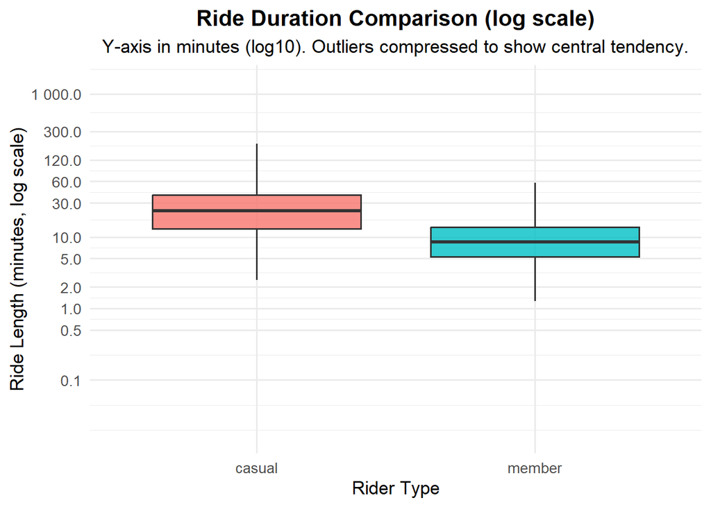

```r
library(ggplot2)
library(dplyr)
library(scales)

divvy_data %>%
  filter(ride_length > 0) %>%            # remove zeros/negatives
  ggplot(aes(x = member_casual, y = ride_length, fill = member_casual)) +
  geom_boxplot(outlier.shape = NA, alpha = 0.8) +  # hide extreme outliers for visibility
  #geom_jitter(width = 0.15, alpha = 0.12, size = 0.6) + # optional: show point cloud
  scale_y_log10(
    labels = label_number(accuracy = 0.1),
    breaks = c(0.1, 0.5, 1, 2, 5, 10, 30, 60, 120, 300, 1000)
  ) +
  labs(
    title = "Ride Duration Comparison (log scale)",
    subtitle = "Y-axis in minutes (log10). Outliers compressed to show central tendency.",
    x = "Rider Type",
    y = "Ride Length (minutes, log scale)"
  ) +
  theme_minimal(base_size = 13) +
  theme(legend.position = "none",
        plot.title = element_text(hjust = 0.5, face = "bold"),
        plot.subtitle = element_text(hjust = 0.5))
```

**Notes:**  
- `scale_y_log10()` compresses the heavy tail so medians and IQRs are more visible.  
- I hid extreme outliers in the boxplot (`outlier.shape = NA`)( but added a faint jitter cloud in comment so you can still see distribution density if you remove the #).  
- `breaks` include small and large minute values so axis ticks are meaningful.

💭 *Insight:* Casuals display a far wider duration spread — the classic *tourist vs commuter* contrast. Members ride frequently but briefly; casuals ride fewer times but linger longer.

## Round Trips vs One-Way

```r
divvy_data %>%
  mutate(is_round_trip = start_station_id == end_station_id) %>%
  group_by(member_casual, is_round_trip) %>%
  summarise(total_rides = n())
```

| member_casual | is_round_trip | total_rides |
| --- | --- | --- |
| casual | FALSE | 57903 |
| casual | TRUE | 9679 |
| member | FALSE | 706273 |
| member | TRUE | 13852 |

## Temporal Insights

### Day + Hour Trends

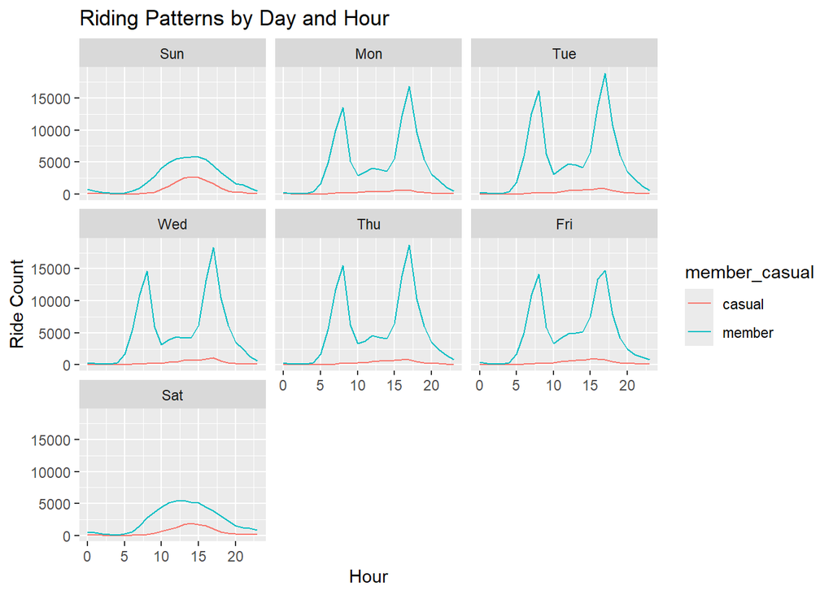

```r
divvy_data %>%
  group_by(member_casual, day_of_week, hour) %>%
  summarise(total_rides = n()) %>%
  ggplot(aes(x = hour, y = total_rides, color = member_casual)) +
  geom_line() +
  facet_wrap(~ day_of_week) +
  labs(title = "Riding Patterns by Day and Hour",
       x = "Hour", y = "Ride Count")
```

💭 *Interpretation:* Members peak at **8–9 AM** and **5–6 PM** — commute hours. Casuals peak mid-day and on weekends — pure leisure timing. Two rhythms emerge: *structured weekdays* vs *spontaneous weekends.*

### Seasonal Patterns

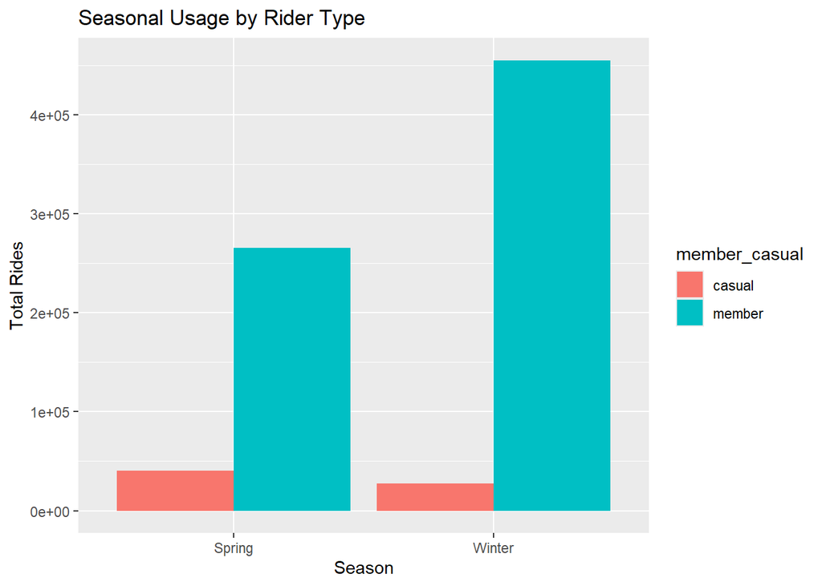

```r
divvy_data %>%
  group_by(member_casual, season) %>%
  summarise(total_rides = n(),
            avg_ride_length = mean(ride_length)) %>%
  ggplot(aes(x = season, y = total_rides, fill = member_casual)) +
  geom_bar(stat = "identity", position = "dodge") +
  labs(title = "Seasonal Usage by Rider Type",
       x = "Season", y = "Total Rides")
```

### Weekly Trends

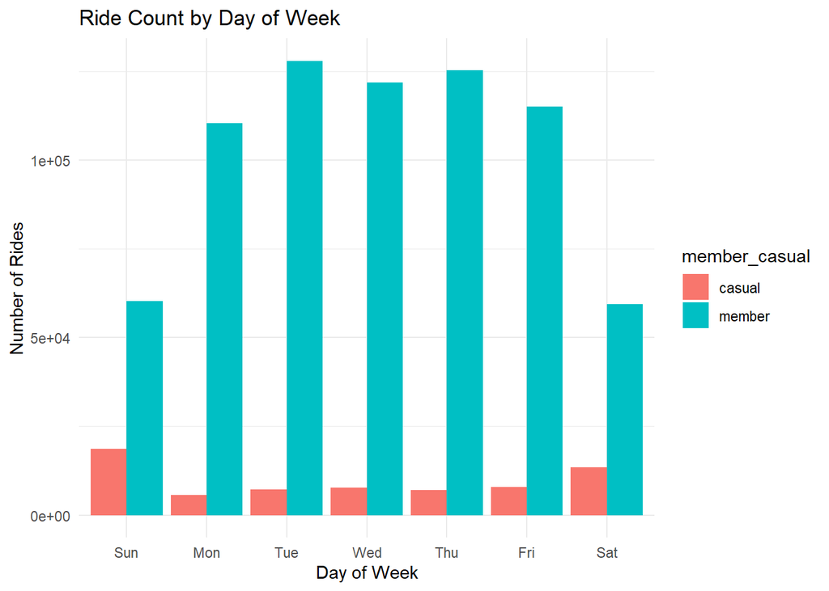

```r
divvy_data %>%
  group_by(member_casual, day_of_week) %>%
  summarise(total_rides = n()) %>%
  ggplot(aes(x = day_of_week, y = total_rides, fill = member_casual)) +
  geom_col(position = "dodge") +
  labs(title = "Ride Count by Day of Week",
       x = "Day of Week", y = "Number of Rides") +
  theme_minimal()
```

💭 *Observation:* Members dominate weekdays; casuals surge on weekends — reinforcing work-vs-leisure behavior.

## Spatial Insights

### Top 10 Start Stations

```r
top_stations <- divvy_data %>%
  group_by(member_casual, start_station_name) %>%
  summarise(rides = n()) %>%
  arrange(member_casual, desc(rides)) %>%
  slice_head(n = 10)
```

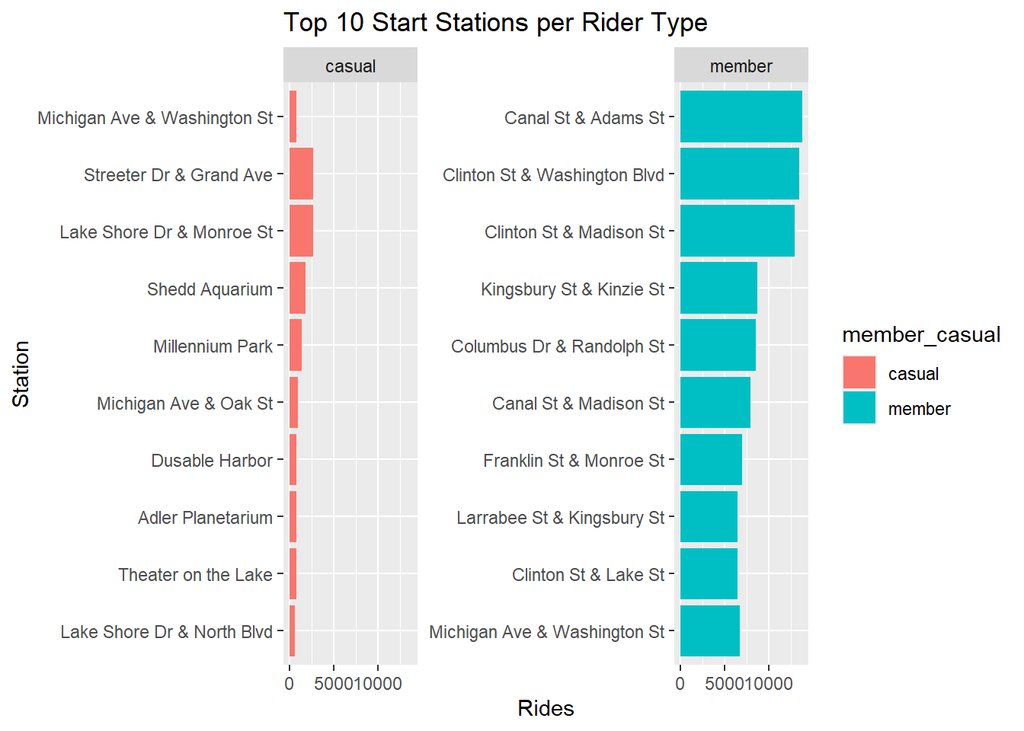

```r
ggplot(top_stations,
       aes(x = reorder(start_station_name, rides),
           y = rides, fill = member_casual)) +
  geom_bar(stat = "identity") +
  coord_flip() +
  facet_wrap(~ member_casual, scales = "free_y") +
  labs(title = "Top 10 Start Stations per Rider Type",
       x = "Station", y = "Rides")
```

💭 *Insight:* Members cluster around **business districts and transit hubs**. Casuals favor **tourist zones and waterfronts** — ideal spots for day-pass marketing.

# STRATEGIC TAKEAWAYS

[output not shown]

# **Recommendations**

## **1️⃣ Seasonal Membership Campaign (Late Spring – Early Summer)**

**What:** Launch a targeted membership promotion focused on converting casual riders during peak leisure months.

**How:**

- Advertise membership perks tied to leisure use (ride discounts, scenic-station offers, partner attraction perks).
- Use QR codes at high-traffic scenic stations for instant sign-up.

**When:**

- Begin advertising in **late April**
- Run campaign through **July**, when casual ridership is highest.

**By Whom:**

- **Marketing Team** (campaign design, messaging, creatives)
- **Partnerships Team** (tourist sites, attractions, scenic zones)
- **Operations Team** (QR placement at stations)

## **2️⃣ Public Transport Advertising for Casual Riders**

**What:** Promote Cyclistic membership on public transport channels frequently used by casual riders.

**How:**

- Place ads with QR codes inside buses, trains, and metro stations connected to tourist and weekend-heavy areas.
- Highlight convenience and cost savings for multi-modal travelers.

**When:**

- Run continuously, with increased frequency on **weekends** and **tourist season** (May–September).

**By Whom:**

- **Marketing Team** (ad design, CTA optimisation)
- **Transit Advertising Partners** (bus, metro, rail networks)
- **Brand Outreach Team** (negotiating placements)

## **3️⃣ Add Extra Ride-Time Benefits to Annual Membership**

**What:** Provide additional free ride-time hours as a built-in benefit for annual members.

**How:**

- Offer monthly bonus minutes or extended ride duration before overage fees.
- Promote these perks during onboarding and all seasonal campaigns.

**When:**

- Introduce the benefit at the start of **summer** (June)
- Maintain year-round as a permanent membership feature.

**By Whom:**

- **Product Team** (membership feature design)
- **Finance Team** (cost modeling)
- **Marketing Team** (promotion and messaging)

# CONCLUSION

These patterns reveal two distinct motivations: **efficiency vs experience**.  
Bridging that gap through well-timed seasonal promotions, flexible membership plans, and on-site marketing at tourist stations can transform occasional riders into loyal members.